# Modelo de Regressão Linear Múltipla

Heterocedasticidade

Autor

```r
# pacotes utilizados
library(tidyverse)  # Metapacote que inclui dplyr, readr, ggplot2, etc.
library(broom)      # converte os resultados de modelos estatísticos em tibbles
library(Ecdat)      # contém conjuntos de dados para econometria
```

# 1 Exemplos

**Objetivo:** Estimar a relação entre as pontuações padronizadas em testes (variável resposta) e (1) a proporção aluno-professor e (2) a renda, *ou seja*,

$$(\text{Test score})_i = \beta_0 + \beta_1 \text{Ratio}_i +
\beta_2 \text{Income}\_{i} + u\_i \tag{1}$$

**Problema potencial:** Heterocedasticidade… e não observamos $u_i$.

**Solução:**

1. Estimar a relação em $(1)$ usando Mínimos Quadrados Ordinários (MQO).
2. Usar os resíduos $(e_i)$ para testar a heterocedasticidade:
   - Teste de Goldfeld-Quandt
   - Teste de Breusch-Pagan
   - Teste de White

Usaremos os dados `Caschool` contidos no pacote `Ecdat`.

```r
# seleciona e renomeia as variáveis desejadas
# atribui o resultado para teste_df
teste_df <- select(Caschool, test_score = testscr, ratio = str, income = avginc)

# formata teste_df como tibble
teste_df <- as_tibble(teste_df)

# visualiza as 2 primeiras linhas do conjunto de dados
head(teste_df, 2)
```

```
# A tibble: 2 × 3
  test_score ratio income
       <dbl> <dbl>  <dbl>
1       691.  17.9  22.7
2       661.  21.5   9.82
```

```r
# estrutura geral
dplyr::glimpse(teste_df)
```

```
Rows: 420
Columns: 3
$ test_score <dbl> 690.80, 661.20, 643.60, 647.70, 640.85, 605.55, 606.75, 609…
$ ratio      <dbl> 17.88991, 21.52466, 18.69723, 17.35714, 18.67133, 21.40625,…
$ income     <dbl> 22.690001, 9.824000, 8.978000, 8.978000, 9.080333, 10.41500…
```

Vamos começar estimando o modelo:

$$(\text{Test score})_i = \beta_0 + \beta_1 \text{Ratio}_i +
\beta_2 \text{Income}\_{i} + u\_i \tag{1}$$

```r
# estima o modelo
model_est <- lm(test_score ~ ratio + income, data = teste_df)
# resultados
tidy(model_est)
```

```
# A tibble: 3 × 5
  term        estimate std.error statistic   p.value
  <chr>          <dbl>     <dbl>     <dbl>     <dbl>
1 (Intercept)  639.       7.45       85.7  5.70e-267
2 ratio         -0.649    0.354      -1.83 6.79e-  2
3 income         1.84     0.0928     19.8  4.38e- 62
```

Agora, vamos ver o que os resíduos sugerem sobre heterocedasticidade.

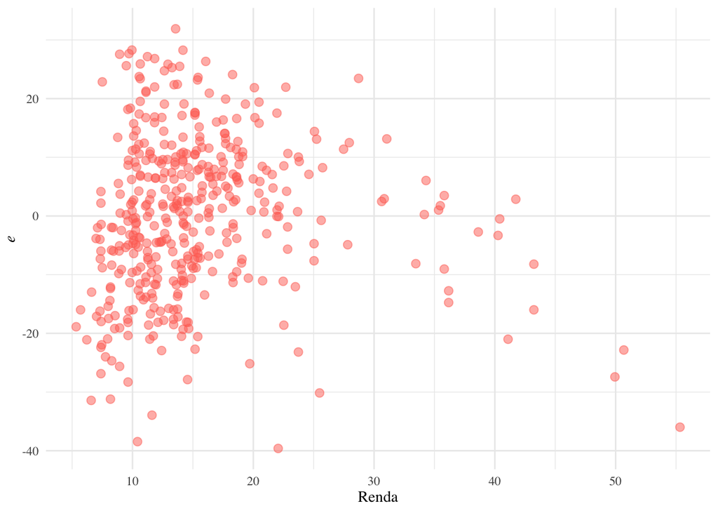

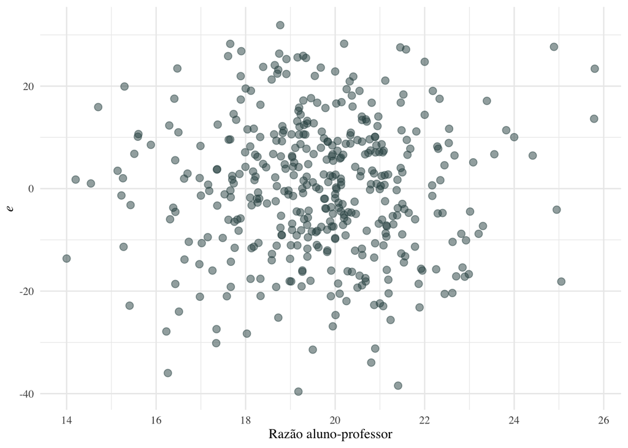

```r
# adiciona os resíduos à data frame
teste_df$e <- residuals(model_est)

# Criando o primeiro gráfico: resíduos vs renda
ggplot(data = teste_df, aes(x = income, y = e)) +
  geom_point(size = 2.5, alpha = 0.5, color = "#FF6F61") +
  labs(x = "Renda", y = expression(italic(e))) +
  theme_minimal(base_family = "serif")
# Criando o segundo gráfico: resíduos vs razão aluno-professor
ggplot(data = teste_df, aes(x = ratio, y = e)) +
  geom_point(size = 2.5, alpha = 0.5, color = "darkslategrey") +
  labs(x = "Razão aluno-professor", y = expression(italic(e))) +
  theme_minimal(base_family = "serif")
```

A renda parece potencialmente heterocedástica, vamos testar usando o teste de Goldfeld-Quandt.

## 1.1 Teste de Goldfeld-Quandt

Implementando o algoritmo:

```r
# ordena a df pela renda em ordem crescente
test_df <- dplyr::arrange(teste_df, income)

# reestima o modelo para as últimas e primeiras 158 observações
modelo_est1 <- lm(test_score ~ ratio + income, data = tail(teste_df, 158))
modelo_est2 <- lm(test_score ~ ratio + income, data = head(teste_df, 158))

# armazena os resíduos de cada regressão
e_modelo1 <- residuals(modelo_est1)
e_modelo2 <- residuals(modelo_est2)

# Calcula a RSS para cada regressão
(rss_model1 <- sum(e_modelo1^2))
```

```
[1] 8026.442
```

```r
(rss_model2 <- sum(e_modelo2^2))
```

```
[1] 13161.49
```

Cálculo da estatística de teste de Goldfeld-Quandt:

$F_{n^\star-k,\,n^\star-k} = \dfrac{\text{RSS}_2}{\text{RSS}_1}$ $\approx\dfrac{13,161.49}{8,026.44}$ $\approx1.64$

Teste via $F_{158-3,\,158-3}$

```r
# estatatística do teste de G-Q
(f_gq <- rss_model2/rss_model1)
```

```
[1] 1.639766
```

```r
# valor-p
pf(q = f_gq, df1 = 158-3, df2 = 158-3, lower.tail = F)
```

```
[1] 0.001113404
```

Reunindo tudo:

$H_0$: $\sigma_1^2 = \sigma_2^2$ *vs.* $H_A$: $\sigma_1^2 \neq \sigma_2^2$

Estatística de teste de Goldfeld-Quandt: $F \approx 1.64$

valor-p = $\approx 0.00111$

Portanto, os dados fornecem evidência para rejeitar a hipótese nula, o valor-p é menor que 0,05.

**Conclusão:** Há evidências estatisticamente significativas de que $\sigma_1^2 \neq \sigma_2^2$. Portanto, encontramos evidências estatisticamente significativas de heterocedasticidade, ao nível de 5%.

E se tivéssemos escolhido focar na razão aluno-professor?

```r
# ordena os dados pela razão aluno-professor
teste_df2 <- dplyr::arrange(teste_df, ratio)

# Reestimar o modelo para as últimas e primeiras 158 observações
modelo_est3 <- lm(test_score ~ ratio + income, data = tail(teste_df2, 158))
modelo_est4 <- lm(test_score ~ ratio + income, data = head(teste_df2, 158))

# Capturar os resíduos de cada regressão
e_modelo3 <- residuals(modelo_est3)
e_modelo4 <- residuals(modelo_est4)

# Calcular a SSE para cada regressão
(rss_model3 <- sum(e_modelo3^2))
```

```
[1] 26243.52
```

```r
(rss_model4 <- sum(e_modelo4^2))
```

```
[1] 29101.52
```

$F_{n^\star-k,\,n^\star-k} = \dfrac{\text{RSS}_4}{\text{RSS}_3} \approx\dfrac{29,101.52}{26,243.52} \approx1.11$

que tem um valor-p de aproximadamente 0.2603.

Portanto, Teríamos falhado em rejeitar a hipótese nula (o valor-p é maior que 0,05), concluindo que não encontramos evidências estatisticamente significativas de heterocedasticidade.

**Lição:** Importância de compreender as limitações dos estimadores, testes, *etc.*

## 1.2 Teste de Breusch-Pagan

Vamos testar o mesmo modelo com o teste de Breusch-Pagan.

*Lembre-se:* Salvamos os resíduos como `e` em nossa data frame, ou seja,

```r
# adiciona os resíduos à data frame
teste_df$e <- residuals(model_est)
```

No teste de Breusch-Pagan, primeiro fazemos a regressão dos resíduos ao quadrado ($e_i^2$) contra as variáveis explicativas e usamos o $R^2$ resultante para calcular a estatística de teste:

```r
# regressão dos resíduos ao quadrado contra as variáveis explicativas
modelo_bp <- lm(I(e^2) ~ ratio + income, data = test_df)

# armazena o R2
r2_bp <- summary(modelo_bp)$r.squared
r2_bp
```

```
[1] 3.23205e-05
```

A estatística de teste de Breusch-Pagan é dada por:

$\text{LM} = n \times R^2_e$ $\approx 420 \times 0.0000323$ $\approx 0.0136$

que testamos contra uma distribuição $\chi_k^2$ (aqui: $k=2$, $k$ é o número de variáveis explicativas, excluindo o intercepto).

```r
# estatistica do teste de B-P
estat_bp <- 420 * r2_bp
estat_bp
```

```
[1] 0.01357461
```

```r
# calcula o valor-p
pchisq(q = estat_bp, df = 2, lower.tail = F)
```

```
[1] 0.9932357
```

Reunindo tudo:

$H_0$: $\alpha_1 = \alpha_2 = 0$ *vs.* $H_A$: $\alpha_1 \neq 0$ e/ou $\alpha_2 \neq 0$

para o modelo

$$u_i^2 = \alpha_0 + \alpha_1 \text{Ratio}_i + \alpha_2 \text{Income}_i + w_i$$

Estatística de teste de Breusch-Pagan: $\widehat{\text{LM}} \approx 0.014$

valor-p $\approx 0.993$

Portanto, não rejeitamos a hipótese nula, o valor-p é maior que 0,05.

**Conclusão:** Não encontramos evidências estatisticamente significativas de heterocedasticidade ao nível de 5%, ou seja, não encontramos evidências de uma relação *linear* entre $u_i^2$ e as variáveis explicativas.

## 1.3 Teste de White

O teste de White adiciona termos ao quadrado e interações ao teste de Breusch-Pagan:

$$\begin{align}
\color{#314f4f}{u_{i}^2} =& \color{#314f4f}{\alpha_{0} + \alpha_{1} \text{Ratio}_{i} + \alpha_{2} \text{Income}_{i} } \\
&+ \color{#e64173}{\alpha_{3} \text{Ratio}_{i}^2 + \alpha_{4} \text{Income}_{i}^2 + \alpha_{5} (\text{Ratio}_{i}\times\text{Income}_{i}}) \\
&+ \color{#314f4f}{w_{i}}
\end{align}$$

o que altera a hipótese nula de

$H_0: \alpha_1 = \alpha_2 = 0$ para

$H_0: \alpha_1 = \alpha_2 = \alpha_3 = \alpha_4 = \alpha_5 = 0$

Assim, precisamos apenas atualizar nosso código R, e estaremos prontos.

*Observação:* R tem uma notação peculiar para termos ao quadrado e interações em `lm()`:

- **Termos ao quadrado** usam `I()`, *por exemplo*, `lm(y ~ I(x^2))`
- **Interações** usam `:` entre as variáveis, *por exemplo*, `lm(y ~ x1:x2)`

*Exemplo:* Regressão de `y` contra o quadrado de `x1` e `x2` e contra a interação de `x1` e `x2`:

```r
# Regressão quadrática com interações
lm(y ~ x1 + x2 + I(x1^2) + I(x2^2) + x1:x2, data = pretend_df)
```

Implementando o algoritmo:

**Passo 1:** Regressão de $e_i^2$ contra as variáveis explicativas, seus quadrados e interações:

```r
# regressão dos residuos quadráticos contra as variaveis explicativas,
# seus quadrados e interações
modelo_white <- lm(
  I(e^2) ~ ratio + income + I(ratio^2) + I(income^2) + ratio:income,
  data = teste_df
)
```

**Passo 2:** Armazene o $Rˆ2$ desta regressão

```r
# armazena o R2
r2_white <- summary(modelo_white)$r.squared
r2_white
```

```
[1] 0.07332222
```

**Passo 3:** Calcule a estatística do teste de White $\text{LM} = n \times R_e^2 \approx 420 \times 0.073$

```r
# calcula a estatistica do teste de White
estat_white <- 420 * r2_white
estat_white
```

```
[1] 30.79533
```

**Passo 4:** Calcule o valor-p the associado (onde $\text{LM} \overset{d}{\sim} \chi_k^2$); aqui, $k=5$

```r
# calcula o valor-p
pchisq(q = estat_white, df = 5, lower.tail = F)
```

```
[1] 1.028039e-05
```

Reunindo tudo…

$H_0: \alpha_1 = \alpha_2 = \alpha_3 = \alpha_4 = \alpha_5 = 0$ *vs.* $H_A: \alpha_i \neq 0$ para algum $i \in \{1,\, 2,\,\ldots,\, 5\}$

$$\begin{align}
u_i^2 =& \alpha_0 + \alpha_1 \text{Ratio}_i + \alpha_2 \text{Income}_i \\
&+ \alpha_3 \text{Ratio}_i^2 + \alpha_4 \text{Income}_i^2 \\
&+ \alpha_5 \text{Ratio}_i \times \text{Income}_i + w_i
\end{align}$$

A estatística do teste de White é: $\text{LM} = n \times R_e^2 \approx 420 \times 0.073 \approx 30.8$

Sob a distribuição $\chi_5^2$, $\widehat{\text{LM}}$ tem um valor-p menor que 0,001.

Portanto, rejeitamos a hipótese nula, e concluímos que há evidências estatisticamente significativas de heterocedasticidade, ao nível de 5%.